# BLOG ANALYSIS

## ABOUT :

#### GPT-3 is also a large-scale transformer-based language model, which is trained on 175 billion parameters and is 10x more than previous models. The company has showcased its extraordinary performances for tasks like translation, Q&A, and unscrambling words.

#### This third-generation language prediction model is autoregressive in nature and works like traditional models where it takes the input vector words and predicts the outputs based on its training. With unsupervised machine learning and few-shot learning, this model works in context.

This Blog is about the recently launched NLP model - GPT-3. Surpassing previous models’ capabilities and accuracy, OpenAI created one of the most controversial pre-trained NLP models — GPT-3, after its major setback with GPT-2. In this Blog, i have majorly focussed on the GPT-3 Model, how it is replacing the Python environment in realtime industry scenario, why it has been adopted so fast and what are the consequences in the coming times. How it can contribute to different NLP models in a newly born environment. Lets try to analyse the Blog using NLP practise.

### We need to perform investigative and detective analysis of our data to see if we can unearth any insights.

```python
import pandas as pd
import numpy as np
import scipy as sp
import re
import string
from sklearn.model_selection import train_test_split
from sklearn.feature_extraction.text import CountVectorizer, TfidfVectorizer
from sklearn.naive_bayes import MultinomialNB
from sklearn.linear_model import LogisticRegression
from sklearn import metrics
from textblob import TextBlob, Word
from nltk.stem.snowball import SnowballStemmer
%matplotlib inline
import nltk
nltk.download("book")
from nltk.book import *
nltk.download('punkt')
nltk.download('wordnet')
```

```
*** Introductory Examples for the NLTK Book ***
Loading text1, ..., text9 and sent1, ..., sent9
Type the name of the text or sentence to view it.
Type: 'texts()' or 'sents()' to list the materials.
text1: Moby Dick by Herman Melville 1851
text2: Sense and Sensibility by Jane Austen 1811
text3: The Book of Genesis
text4: Inaugural Address Corpus
text5: Chat Corpus
text6: Monty Python and the Holy Grail
text7: Wall Street Journal
text8: Personals Corpus
text9: The Man Who Was Thursday by G . K . Chesterton 1908
```

```
True
```

```python
import warnings
warnings. filterwarnings('ignore')
```

```python
#read BLOG ON GPT-3 BY- SAURABH, ARUSHI and SHIKHAR.txt blog file

file = 'C:/Users/lenovo/Desktop/BLOG ANALYSIS BY SAURABH, ARUSHI and SHIKHAR/BLOG ON GPT-3 BY- SAURABH, ARUSHI and SHIKHAR.txt'
workfile = open(file, "r")
blog_gpt = workfile.read()
blog_gpt
```

```
'Introduction\nGPT-3\nSurpassing previous models’ capabilities and accuracy, OpenAI created one of the most controversial pre-trained NLP models — GPT-3, after its major setback with GPT-2. Similar to BERT, GPT-3 is also a large-scale transformer-based language model, which is trained on 175 billion…
```

### Context analysis in NLP involves breaking down sentences to extract the n-grams, noun phrases, themes, and facets present within. In this article, I’ll explain the value of context in NLP and explore how we break down unstructured text documents to help you understand context.

## The Value of Context in NLP

#### What are they talking about?

#### Why do they feel that way?

This last question is a question of context.

```python
#Counting Vocabulary
len(blog_gpt)
```

```
12902
```

This counts all the characters of the file included spaces and special characters.

## Tokenising

```python
# Tokenizing word from text document
# Tokenization refers to dividing text or a sentence into a sequence of tokens, which roughly correspond to “words”.
tokens = nltk.word_tokenize(blog_gpt)

# We can check the length of created tokens or splitted word
len(tokens)
```

```
2253
```

This means - There are total 2253 tokens or words in the blog file. Lets have a look at these words-

```python
tokens
```

```
['Introduction',
 'GPT-3',
 'Surpassing',
 'previous',
 'models',
 '’',
 'capabilities',
 'and',
 'accuracy',
 ',',
 'OpenAI',
 'created',
 'one',
 'of',
 'the',
 'most',
 'controversial',
 'pre-trained',
 'NLP',
 'models',
 '—',
 'GPT-3',
 ',',
 'after',
 'its',
 'major',
 'setback',
 'with',
 'GPT-2',
 '.',
 'Similar',
 'to',
 'BERT',
 ',',
 'GPT-3',
 'is',
 'also',
 'a',
 'large-scale',
 'transformer-based',
```

[output cut: 946 more lines]

```
 'good',
 '”',
 'as',
 'a',
 'question-answering',
 'or',
 'dialog',
 'system',
 ',',
 'and',
 'that',
 'different',
 'strategies',
 'produce',
 ...]
```

## Unique Tokens

```python
#Lets have a look at unique set of words in the tokens
len(set(tokens))
```

```
840
```

That means the Blog has 840 unique words. We will further check the lexical richness of the blog.

```python
# By creating an NLTK text from this tokens, we can carry out all of the other linguistic processing
nltk_blog = nltk.Text(tokens)
nltk_blog
```

```
<Text: Introduction GPT-3 Surpassing previous models ’ capabilities and...>
```

```python
# Concordance- it will show the context where the word is matched.
nltk_blog.concordance("GPT-3")
```

```
Displaying 25 of 47 matches:
Introduction GPT-3 Surpassing previous models ’ capabil
ntroversial pre-trained NLP models — GPT-3 , after its major setback with GPT-2
tback with GPT-2 . Similar to BERT , GPT-3 is also a large-scale transformer-ba
nts : * Autoregressive in nature . * GPT-3 showcases how a language model train
tive Pre-trained Transformer three ( GPT-3 ) is an autoregressive language mann
synthetic talent lookup laboratory . GPT-3 's full model has an ability of one
llion desktop mastering parameters . GPT-3 , which used to be delivered in May
esentations . Prior to the launch of GPT-3 , the biggest language mannequin use
ss than 10 percentage in contrast to GPT-3 . The excellent of the textual conte
extual content generated by means of GPT-3 is so excessive that it is tough to
ique May 28 , 2020 paper introducing GPT-3 . In their paper , they warned of GP
-3 . In their paper , they warned of GPT-3 's manageable risks and referred to
n Australian philosopher , described GPT-3 as `` one of the most fascinating an
 OpenAI described the improvement of GPT-3 , a third generation `` state-of-the
 The group elevated the potential of GPT-3 by using over two orders of magnitud
 predecessor , GPT-2 , [ 12 ] making GPT-3 the greatest non-sparse [ further cl
 mannequin to date . [ 1 ] :14 [ 2 ] GPT-3 's greater quantity of parameters su
he weighted pre-training dataset for GPT-3 comes from a filtered model of Commo
ikipedia representing 3 % . [ 1 ] :9 GPT-3 used to be educated on thousands of
SX , Python , amongst others . Since GPT-3 's education statistics was once all
 request get admission to its common GPT-3 API—a `` machine getting to know too
 personal early launch of the OpenAI GPT-3 API , GPT-3 was once `` eerily good
rly launch of the OpenAI GPT-3 API , GPT-3 was once `` eerily good '' at writin
 solely a few easy prompts . Because GPT-3 can `` generate information articles
rom articles written via humans , '' GPT-3 has the `` potential to increase eac
```

```python
#The common_contexts() method allows you to examine the contexts that are shared by two or more words.
nltk_blog.common_contexts(["NLP"])
```

```
pre-trained_models various_tasks (_) pre-trained_model with_the
new_fashions pre-trained_fashions normal_duties
```

## Lexical Richness

```python
#ratio of different unique word stems (types) to the total number of words (tokens).
len(set(nltk_blog))/len(nltk_blog)*100

#The higher the number, the more lexically rich it is.
```

```
37.28362183754994
```

This means as compared to the length of words or tokens with the unique tokens, the blog is not kexically rich. Unique words as compared to lenght of tokens differs in a huge number

## Dispersion Plot

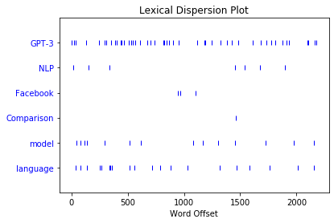

```python
#we can also determine the location of a word in the text: how many words from the beginning it appears.
#This positional information can be displayed using a dispersion plot.

nltk_blog.dispersion_plot(["GPT-3","NLP","Facebook","Comparison","model","language"])
```

This shows the positional INformation of words like we can see 'GPT-3' is the most common word, that is lying throughout the Blog, also the word 'language', we can see it more often. Occurence of word' Comparison' is only once in the Blog which is near 1500th word. Such kind of inference we can make using a word search dispersion plot.

## Frequency Distribution

```python
# Frequency dist of NLTK_BLOG using built in fucn
fdist1= FreqDist(nltk_blog)
print(fdist1)
fdist1
```

```
<FreqDist with 840 samples and 2253 outcomes>
```

```
FreqDist({',': 112, 'the': 81, '.': 75, 'of': 70, 'to': 52, 'GPT-3': 47, 'and': 44, 'a': 40, 'in': 38, 'is': 26, ...})
```

This shows the number of occurence of words in the blog. For ex. ',' has occurred 112 times in the blog, 'the' occurred 81 times, and so on.

## Common Words in the Blog

```python
# 50 common words
fdist1.most_common(50)
```

```
[(',', 112),
 ('the', 81),
 ('.', 75),
 ('of', 70),
 ('to', 52),
 ('GPT-3', 47),
 ('and', 44),
 ('a', 40),
 ('in', 38),
 ('is', 26),
 ('for', 24),
 ('on', 23),
 ('language', 20),
 ('with', 18),
 ('that', 17),
 ('it', 16),
 ('as', 16),
 ('BERT', 15),
 ('mannequin', 15),
 ('model', 14),
 ('an', 13),
 ('’', 12),
 ('``', 12),
 ("''", 12),
 ('be', 11),
 ('from', 11),
 ('fashions', 11),
 ('one', 10),
 ('The', 10),
 ('can', 10),
 ('s', 10),
 ('OpenAI', 9),
 ('its', 9),
 ('billion', 9),
 ('*', 9),
 ('has', 8),
 ('like', 8),
 ('learning', 8),
 ('%', 8),
 ('use', 8),
 ('by', 8),
 ('NLP', 7),
 ('parameters', 7),
 ('tasks', 7),
 (':', 7),
 ("'s", 7),
 ('2020', 7),
 ('or', 7),
 ('their', 7),
 ('not', 7)]
```

## Distribution Plot for Common Words

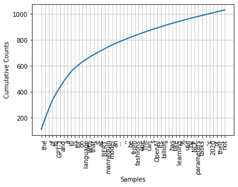

```python
# We can plot the distribution of common words also
#plotting
fdist1.plot(50, cumulative=True)
```

## Words that occur only once

```python
#we can check the words that occur only once
once= fdist1.hapaxes()
print("Total Word count that Occurred Once",len(once))
print("\n",once)
```

```
Total Word count that Occurred Once 555

 ['Introduction', 'Surpassing', 'capabilities', 'controversial', 'after', 'major', 'setback', 'Similar', 'also', 'large-scale', 'transformer-based', '175', '10x', 'company', 'showcased', 'extraordinary', 'performances', 'unscrambling', 'This', 'traditional', 'where', 'takes', 'input', 'vector', 'pre…
```

## LONG WORDS FILTER USING LOOP

```python
#Fine-grained selection of words through set theory: LONG WORDS FILTER USING LOOP
V=set(nltk_blog)
long_words=[w for w in V if len(w) > 10]

count= len(long_words)
print("Length of Long Words having more than 10 characters is -", count)
sorted(long_words)
```

```
Length of Long Words having more than 10 characters is - 98
```

```
['Achievements',
 'Applications',
 'Autoregressive',
 'Bidirectional',
 'Capabilities',
 'Characteristics',
 'Classification',
 'Francisco-based',
 'Introduction',
 'Nonetheless',
 'Pre-trained',
 'Representations',
 'Transformer',
 'Transformers',
 'additionally',
 'all-encompassing',
 'alternative',
 'application',
 'applications',
 'appointment',
 'association',
 'autoregressive',
 'bidirectional',
 'byte-pair-encoded',
 'calculations',
 'capabilities',
 'capacity.GPT-3',
 'challenging',
 'clarification',
 'commercially',
 'conditioning',
 'consequences',
 'considering',
 'constraints',
 'constructing',
 'controversial',
 'conversational',
 'dangerously',
 'democratised',
 'developments',
```

[output cut: 43 more lines]

```
 'researchers',
 'revolutionary',
 'seventy-five',
 'similarities',
 'state-of-the-art',
 'third-generation',
 'traditional',
 'transformer',
 'transformer-based',
 'translation',
 'tremendously',
 'unrealistic',
 'unscrambling',
 'unsupervised',
 'unsupported']
```

## N-Grams

```python
#Collocations and Bigrams
list(bigrams(nltk_blog[:50]))
#bigram for first 50 words
```

```
[('Introduction', 'GPT-3'),
 ('GPT-3', 'Surpassing'),
 ('Surpassing', 'previous'),
 ('previous', 'models'),
 ('models', '’'),
 ('’', 'capabilities'),
 ('capabilities', 'and'),
 ('and', 'accuracy'),
 ('accuracy', ','),
 (',', 'OpenAI'),
 ('OpenAI', 'created'),
 ('created', 'one'),
 ('one', 'of'),
 ('of', 'the'),
 ('the', 'most'),
 ('most', 'controversial'),
 ('controversial', 'pre-trained'),
 ('pre-trained', 'NLP'),
 ('NLP', 'models'),
 ('models', '—'),
 ('—', 'GPT-3'),
 ('GPT-3', ','),
 (',', 'after'),
 ('after', 'its'),
 ('its', 'major'),
 ('major', 'setback'),
 ('setback', 'with'),
 ('with', 'GPT-2'),
 ('GPT-2', '.'),
 ('.', 'Similar'),
 ('Similar', 'to'),
 ('to', 'BERT'),
 ('BERT', ','),
 (',', 'GPT-3'),
 ('GPT-3', 'is'),
 ('is', 'also'),
 ('also', 'a'),
 ('a', 'large-scale'),
 ('large-scale', 'transformer-based'),
 ('transformer-based', 'language'),
 ('language', 'model'),
 ('model', ','),
 (',', 'which'),
 ('which', 'is'),
 ('is', 'trained'),
 ('trained', 'on'),
 ('on', '175'),
 ('175', 'billion'),
 ('billion', 'parameters')]
```

N-grams are combinations of one or more words that represent entities, phrases, concepts, and themes that appear in text. Generally speaking, the lower the value of “n”, the more general the phrase or entity.

Two words is the perfect number for capturing the key phrases and themes that provide context for entity sentiment.

### But be warned: N-grams can come a lot “noise”. Phrases such as “with that”, which technically are bi-grams, offer no value in context determination, and do little more than clutter your view.

## Using Stop Words to Clean Up N-Gram Analysis

```python
from nltk.corpus import stopwords
from nltk.tokenize import word_tokenize
```

```python
stop_words = set(stopwords.words('english'))

word_tokens = word_tokenize(blog_gpt)

filtered_sentence = [w for w in word_tokens if not w in stop_words]

filtered_sentence = []

for w in word_tokens:
    if w not in stop_words:
        filtered_sentence.append(w)

print(filtered_sentence)
```

```
['Introduction', 'GPT-3', 'Surpassing', 'previous', 'models', '’', 'capabilities', 'accuracy', ',', 'OpenAI', 'created', 'one', 'controversial', 'pre-trained', 'NLP', 'models', '—', 'GPT-3', ',', 'major', 'setback', 'GPT-2', '.', 'Similar', 'BERT', ',', 'GPT-3', 'also', 'large-scale', 'transformer-b…
```

```python
#Collocations and Bigrams
list(bigrams(filtered_sentence[:50]))
#bigram for first 50 words
```

```
[('Introduction', 'GPT-3'),
 ('GPT-3', 'Surpassing'),
 ('Surpassing', 'previous'),
 ('previous', 'models'),
 ('models', '’'),
 ('’', 'capabilities'),
 ('capabilities', 'accuracy'),
 ('accuracy', ','),
 (',', 'OpenAI'),
 ('OpenAI', 'created'),
 ('created', 'one'),
 ('one', 'controversial'),
 ('controversial', 'pre-trained'),
 ('pre-trained', 'NLP'),
 ('NLP', 'models'),
 ('models', '—'),
 ('—', 'GPT-3'),
 ('GPT-3', ','),
 (',', 'major'),
 ('major', 'setback'),
 ('setback', 'GPT-2'),
 ('GPT-2', '.'),
 ('.', 'Similar'),
 ('Similar', 'BERT'),
 ('BERT', ','),
 (',', 'GPT-3'),
 ('GPT-3', 'also'),
 ('also', 'large-scale'),
 ('large-scale', 'transformer-based'),
 ('transformer-based', 'language'),
 ('language', 'model'),
 ('model', ','),
 (',', 'trained'),
 ('trained', '175'),
 ('175', 'billion'),
 ('billion', 'parameters'),
 ('parameters', '10x'),
 ('10x', 'previous'),
 ('previous', 'models'),
 ('models', '.'),
 ('.', 'The'),
 ('The', 'company'),
 ('company', 'showcased'),
 ('showcased', 'extraordinary'),
 ('extraordinary', 'performances'),
 ('performances', 'tasks'),
 ('tasks', 'like'),
 ('like', 'translation'),
 ('translation', ',')]
```

```python
#Conditional Python
#unique words containing 'able' in NLTK_BLOG
sorted(w for w in set(nltk_blog) if w.endswith('able'))
```

```
['applicable', 'available', 'manageable', 'unreliable', 'workable']
```

```python
def get_top_ngram(corpus, n=None):
    vec = CountVectorizer(ngram_range=(n, n)).fit(corpus)
    bag_of_words = vec.transform(corpus)
    sum_words = bag_of_words.sum(axis=0)
    words_freq = [(word, sum_words[0, idx])
                  for word, idx in vec.vocabulary_.items()]
    words_freq =sorted(words_freq, key = lambda x: x[1], reverse=True)
    return words_freq[:10]
```

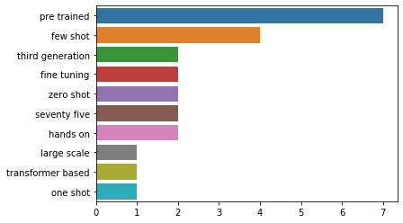

```python
import seaborn as sns
top_n_bigrams=get_top_ngram(nltk_blog,2)[:10]
x,y=map(list,zip(*top_n_bigrams))
sns.barplot(x=y,y=x)
```

We can observe that the bigrams such as ‘pre-trained’, ’few shot’ that are related to GPT-3 Blog dominate the Blog.

## TEXT BLOB

```python
#import textblob
from textblob import TextBlob
from wordcloud import WordCloud
from textblob import Word
```

### TextBlob is a Python library for processing textual data.

### It provides a simple API for diving into common natural language processing (NLP) tasks

### such as part-of-speech tagging, noun phrase extraction, sentiment analysis, classification, translation, and more.

```python
#STRING CONVERTED TO SENTENCES
blob_art = TextBlob(blog_gpt) # NOT-LIST OBJECT SHOULD BE USED.
blob_art
```

[output not shown]

[output cut: 10 more lines]

[output not shown]

## Print words of first sentences

```python
# To Print words of first sentences
for words in blob_art.sentences[0].words:
  print(words)
```

```
Introduction
GPT-3
Surpassing
previous
models
’
capabilities
and
accuracy
OpenAI
created
one
of
the
most
controversial
pre-trained
NLP
models
—
GPT-3
after
its
major
setback
with
GPT-2
```

## NOUN PHRASE EXTRACTION: Analysing the WHO in the Sentences

### The form of n-gram that takes center stage in NLP context analysis is the noun phrase.

Noun phrases are part of speech patterns that include a noun. They can also include whatever other parts of speech make grammatical sense, and can include multiple nouns.

```python
# NOUN-PHRASES extraction is particularly important when you want to analyze the “who” in a sentence.
for np in blob_art.sentences[1].noun_phrases:
  print(np)
```

```
bert
gpt-3
language model
previous models
```

## Part-of-speech tagging

Noun phrase extraction takes part of speech type into account when determining relevance. Many stop words are removed simply because they are a part of speech that is uninteresting for understanding context.

```python
#it tells whether a word is a noun, or an adjective, or a verb, etc.
for words, tag in blob_art.sentences[2].tags:
  print(words, tag)

  #Here, NN represents a noun, DT represents as a determiner, etc.
```

```
The DT
company NN
has VBZ
showcased VBN
its PRP$
extraordinary JJ
performances NNS
for IN
tasks NNS
like IN
translation NN
Q NNP
& CC
A NNP
and CC
unscrambling JJ
words NNS
```

## Words Inflection and Lemmatization.

```python
#Inflection is a process of word formation
#in which characters are added to the base form of a word to express grammatical meanings.
print(blob_art.sentences[2].words[1])
print(blob_art.sentences[2].words[1].pluralize())
```

```
company
companies
```

```python
#We can also use the tags to inflect a particular type of words as shown below.
for word,pos in blob_art.sentences[10].tags:
  if pos == 'NN':
    print("NN word is- " + word, "\t Plurize word is- " + word.pluralize())
```

```
NN word is- * 	 Plurize word is- *s
NN word is- building 	 Plurize word is- buildings
NN word is- code 	 Plurize word is- codes
NN word is- * 	 Plurize word is- *s
NN word is- language 	 Plurize word is- languages
NN word is- mannequin 	 Plurize word is- mannequins
NN word is- use 	 Plurize word is- uses
NN word is- mastering 	 Plurize word is- masterings
NN word is- text 	 Plurize word is- texts
```

```python
#Words can be lemmatized using the lemmatize function.
#lemmetization
w=Word(blob_art.sentences[10].words[7])
print(w)
w.lemmatize("v")
#v here represents verb
```

```
generating
```

```
'generate'
```

## **Sentiment analysis**

is basically the process of determining the attitude or the emotion of the writer.

The sentiment function of textblob returns two properties, polarity, and subjectivity. Polarity is float which lies in the range of [-1,1] where 1 means positive statement and -1 means a negative statement.

Subjective sentences generally refer to personal opinion, emotion or judgment whereas objective refers to factual information. Subjectivity is also a float which lies in the range of [0,1].

```python
print (blob_art.sentences[1])
blob_art.sentiment
```

```
Similar to BERT, GPT-3 is also a large-scale transformer-based language model, which is trained on 175 billion parameters and is 10x more than previous models.
```

```
Sentiment(polarity=0.13149901115587392, subjectivity=0.5122741637447521)
```

```python
#polarity ranges from -1 (most negative) to 1 (most positive)
blob_art.sentiment.polarity
```

```
0.13149901115587392
```

```python
#Create a short summary of Text
import random

blob_sum= blob_art
nouns= list()

for word, tag in blob_sum.tags:
  if tag == 'NN':
    nouns.append(word.lemmatize())
print ("This Blog is about....")
for item in random.sample(nouns, 10):
  word= Word(item)
  print (word.pluralize())
```

```
This Blog is about....
cures
codes
%s
dialogs
buildings
mannequins
additions
accuracies
users
pushes
```

## Wordcloud

Wordcloud is a great way to represent text data. The size and color of each word that appears in the wordcloud indicate it’s frequency or importance.

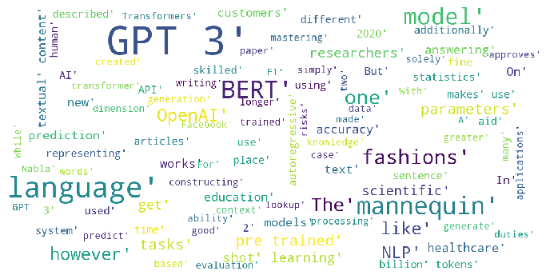

```python
from wordcloud import WordCloud, STOPWORDS
stopwords = set(stop_words)

def show_wordcloud(data):
    wordcloud = WordCloud(
        background_color='white',
        stopwords=stopwords,
        max_words=100,
        max_font_size=30,
        scale=3,
        random_state=1)

    wordcloud=wordcloud.generate(str(data))

    fig = plt.figure(1, figsize=(12, 12))
    plt.axis('off')

    plt.imshow(wordcloud)
    plt.show()

show_wordcloud(filtered_sentence)
```

## Again, you can see that the terms associated with the GPT are highlighted which indicates that these words occurred frequently in the Blog.

## Conclusion:

### Characteristics & Key Achievements:

• Autoregressive in nature. • GPT-3 showcases how a language model trained on a massive range of data can solve various NLP tasks without fine-tuning. • Can be applied to write news, generate articles as well as codes. • Achieved a score of 81.5 F1 on conversational question answering benchmark in zero-shot learning; 84.0 F1 in one-shot learning; and 85.0 F1 in few-shot learning. • Achieved 64.3% accuracy on TriviaAQ benchmark and 76.2% accuracy on LAMBADA, with zero-shot learning.

### Applications:

• For building applications and websites • For generating ML code • Writing articles and podcasts • For legal documents and generating resumes